# Projekt_z_R

Dominik Łukasiewicz

2023-12-08

# 1 Wstęp

Celem projektu jest analiza bazy danych Lego na przestrzeni lat.

# 2 Przygotowanie środowiska

## 2.1 Wykorzystane biblioteki

- knitr - tworzenie raportów w R
- dplyr - przetwarzanie danych
- DT - wyświetlanie interaktywnych tabel
- png - wczytywanie i pokazywanie zdjęć
- skimr - tworzenie podsumowania danych
- ggplot2 - tworzenie wykresów
- plotly - tworzenie interaktywnych wykresów
- caret - uczenie maszynowe

## 2.2 Ustawienie powtarzalność wyników

W celu zapewnienia powtarzalności wyników ziarno zostało ustawione na 23.

```r
set.seed(23)
```

# 3 Schemat danych

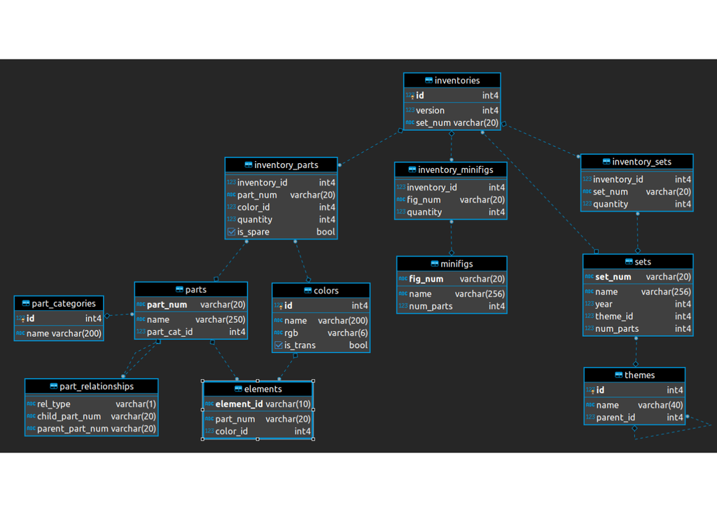

```r
rebrickable_schema <- readPNG("data/rebrickable_schema_v3.png")
grid::grid.raster(rebrickable_schema)
```

# 4 Wstępne przetwarzanie danych

## 4.1 Wczytanie danych

```r
colors_raw <- read.csv("data/colors.csv", header = T, sep = ",")
elements_raw <- read.csv("data/elements.csv", header = T, sep = ",")
inventories_raw <- read.csv("data/inventories.csv", header = T, sep = ",")
inventory_minifigs_raw <- read.csv("data/inventory_minifigs.csv", header = T, sep = ",")
inventory_parts_raw <- read.csv("data/inventory_parts.csv", header = T, sep = ",")
inventory_sets_raw <- read.csv("data/inventory_sets.csv", header = T, sep = ",")
minifigs_raw <- read.csv("data/minifigs.csv", header = T, sep = ",")
part_categories_raw <- read.csv("data/part_categories.csv", header = T, sep = ",")
part_relationships_raw <- read.csv("data/part_relationships.csv", header = T, sep = ",")
parts_raw <- read.csv("data/parts.csv", header = T, sep = ",")
sets_raw <- read.csv("data/sets.csv", header = T, sep = ",")
themes_raw <- read.csv("data/themes.csv", header = T, sep = ",")
```

## 4.2 Przetwarzanie brakujących danych

### 4.2.1 Colors

Brak modyfikacji surowych danych

```r
colors_clean <- colors_raw
```

### 4.2.2 Elements

Usunięcie nadmiarowej kolumny design_id, która nie miała wykorzystania w schemacie

```r
elements_clean <- elements_raw[, -4]
```

### 4.2.3 Inventories

Brak modyfikacji surowych danych

```r
inventories_clean <- inventories_raw
```

### 4.2.4 Inventory Minifigs

Brak modyfikacji surowych danych

```r
inventory_minifigs_clean <- inventory_minifigs_raw
```

### 4.2.5 Inventory Parts

Usunięcie nadmiarowej kolumny img_url, która nie podlega analizie

```r
inventory_parts_clean <- inventory_parts_raw[, -6]
```

### 4.2.6 Inventory Sets

Brak modyfikacji surowych danych

```r
inventory_sets_clean <- inventory_sets_raw
```

### 4.2.7 Minifigs

Usunięcie nadmiarowej kolumny img_url, która nie podlega analizie

```r
minifigs_clean <- minifigs_raw[, -4]
```

### 4.2.8 Part Categories

Brak modyfikacji surowych danych

```r
part_categories_clean <- part_categories_raw
```

### 4.2.9 Part Relationships

Brak modyfikacji surowych danych

```r
part_relationships_clean <- part_relationships_raw
```

### 4.2.10 Parts

Brak modyfikacji surowych danych

```r
parts_clean <- parts_raw
```

### 4.2.11 Sets

Usunięcie nadmiarowej kolumny img_url, która nie podlega analizie

```r
sets_clean <- sets_raw[, -6]
```

### 4.2.12 Themes

Brak modyfikacji surowych danych

```r
themes_clean <- themes_raw
```

## 4.3 Podstawowe statystyki

### 4.3.1 Colors

```r
knitr::kable((head(colors_clean)))
```

| id | name | rgb | is_trans |
| --- | --- | --- | --- |
| -1 | [Unknown] | 0033B2 | f |
| 0 | Black | 05131D | f |
| 1 | Blue | 0055BF | f |
| 2 | Green | 237841 | f |
| 3 | Dark Turquoise | 008F9B | f |
| 4 | Red | C91A09 | f |

```r
skim(colors_clean)
```

Data summary

| Name | colors_clean |
| --- | --- |
| Number of rows | 263 |
| Number of columns | 4 |
| _______________________ |  |
| Column type frequency: |  |
| character | 3 |
| numeric | 1 |
| ________________________ |  |
| Group variables | None |

**Variable type: character**

| skim_variable | n_missing | complete_rate | min | max | empty | n_unique | whitespace |
| --- | --- | --- | --- | --- | --- | --- | --- |
| name | 0 | 1 | 3 | 28 | 0 | 263 | 0 |
| rgb | 0 | 1 | 6 | 6 | 0 | 223 | 0 |
| is_trans | 0 | 1 | 1 | 1 | 0 | 2 | 0 |

**Variable type: numeric**

| skim_variable | n_missing | complete_rate | mean | sd | p0 | p25 | p50 | p75 | p100 | hist |
| --- | --- | --- | --- | --- | --- | --- | --- | --- | --- | --- |
| id | 0 | 1 | 651.38 | 750.55 | -1 | 83 | 1005 | 1070.5 | 9999 | ▇▁▁▁▁ |

### 4.3.2 Elements

```r
knitr::kable((head(elements_clean)))
```

| element_id | part_num | color_id |
| --- | --- | --- |
| 6443403 | 2277c01pr0009 | 1 |
| 6300211 | 67906c01 | 14 |
| 4566309 | 2564 | 0 |
| 4275423 | 53657 | 1004 |
| 6194308 | 92926 | 71 |
| 6229123 | 26561 | 4 |

```r
skim(elements_clean)
```

Data summary

| Name | elements_clean |
| --- | --- |
| Number of rows | 84138 |
| Number of columns | 3 |
| _______________________ |  |
| Column type frequency: |  |
| character | 1 |
| numeric | 2 |
| ________________________ |  |
| Group variables | None |

**Variable type: character**

| skim_variable | n_missing | complete_rate | min | max | empty | n_unique | whitespace |
| --- | --- | --- | --- | --- | --- | --- | --- |
| part_num | 0 | 1 | 2 | 19 | 0 | 33765 | 0 |

**Variable type: numeric**

| skim_variable | n_missing | complete_rate | mean | sd | p0 | p25 | p50 | p75 | p100 | hist |
| --- | --- | --- | --- | --- | --- | --- | --- | --- | --- | --- |
| element_id | 0 | 1 | 5222065.12 | 1596842.63 | 9327 | 4259774 | 6057754 | 6262025 | 61532443 | ▇▁▁▁▁ |
| color_id | 0 | 1 | 539.67 | 2044.86 | -1 | 8 | 28 | 135 | 9999 | ▇▁▁▁▁ |

### 4.3.3 Inventories

```r
knitr::kable((head(inventories_clean)))
```

| id | version | set_num |
| --- | --- | --- |
| 1 | 1 | 7922-1 |
| 3 | 1 | 3931-1 |
| 4 | 1 | 6942-1 |
| 15 | 1 | 5158-1 |
| 16 | 1 | 903-1 |
| 17 | 1 | 850950-1 |

```r
skim(inventories_clean)
```

Data summary

| Name | inventories_clean |
| --- | --- |
| Number of rows | 37265 |
| Number of columns | 3 |
| _______________________ |  |
| Column type frequency: |  |
| character | 1 |
| numeric | 2 |
| ________________________ |  |
| Group variables | None |

**Variable type: character**

| skim_variable | n_missing | complete_rate | min | max | empty | n_unique | whitespace |
| --- | --- | --- | --- | --- | --- | --- | --- |
| set_num | 0 | 1 | 3 | 20 | 0 | 35644 | 0 |

**Variable type: numeric**

| skim_variable | n_missing | complete_rate | mean | sd | p0 | p25 | p50 | p75 | p100 | hist |
| --- | --- | --- | --- | --- | --- | --- | --- | --- | --- | --- |
| id | 0 | 1 | 61103.60 | 51380.10 | 1 | 14424 | 54379 | 88842 | 194312 | ▇▆▂▂▂ |
| version | 0 | 1 | 1.09 | 0.58 | 1 | 1 | 1 | 1 | 16 | ▇▁▁▁▁ |

### 4.3.4 Inventory Minifigs

```r
knitr::kable((head(inventory_minifigs_clean)))
```

| inventory_id | fig_num | quantity |
| --- | --- | --- |
| 3 | fig-001549 | 1 |
| 4 | fig-000764 | 1 |
| 19 | fig-000555 | 1 |
| 25 | fig-000574 | 1 |
| 26 | fig-000842 | 1 |
| 26 | fig-008641 | 1 |

```r
skim(inventory_minifigs_clean)
```

Data summary

| Name | inventory_minifigs_clean |
| --- | --- |
| Number of rows | 20858 |
| Number of columns | 3 |
| _______________________ |  |
| Column type frequency: |  |
| character | 1 |
| numeric | 2 |
| ________________________ |  |
| Group variables | None |

**Variable type: character**

| skim_variable | n_missing | complete_rate | min | max | empty | n_unique | whitespace |
| --- | --- | --- | --- | --- | --- | --- | --- |
| fig_num | 0 | 1 | 10 | 10 | 0 | 13455 | 0 |

**Variable type: numeric**

| skim_variable | n_missing | complete_rate | mean | sd | p0 | p25 | p50 | p75 | p100 | hist |
| --- | --- | --- | --- | --- | --- | --- | --- | --- | --- | --- |
| inventory_id | 0 | 1 | 43010.44 | 52256.78 | 3 | 7869 | 15681 | 66834 | 194312 | ▇▁▁▁▁ |
| quantity | 0 | 1 | 1.06 | 0.78 | 1 | 1 | 1 | 1 | 100 | ▇▁▁▁▁ |

### 4.3.5 Inventory Parts

```r
knitr::kable((head(inventory_parts_clean)))
```

| inventory_id | part_num | color_id | quantity | is_spare |
| --- | --- | --- | --- | --- |
| 1 | 48379c01 | 72 | 1 | f |
| 1 | 48395 | 7 | 1 | f |
| 1 | stickerupn0077 | 9999 | 1 | f |
| 1 | upn0342 | 0 | 1 | f |
| 1 | upn0350 | 25 | 1 | f |
| 3 | 2343 | 47 | 1 | f |

```r
skim(inventory_parts_clean)
```

Data summary

| Name | inventory_parts_clean |
| --- | --- |
| Number of rows | 1180987 |
| Number of columns | 5 |
| _______________________ |  |
| Column type frequency: |  |
| character | 2 |
| numeric | 3 |
| ________________________ |  |
| Group variables | None |

**Variable type: character**

| skim_variable | n_missing | complete_rate | min | max | empty | n_unique | whitespace |
| --- | --- | --- | --- | --- | --- | --- | --- |
| part_num | 0 | 1 | 1 | 20 | 0 | 51051 | 0 |
| is_spare | 0 | 1 | 1 | 1 | 0 | 2 | 0 |

**Variable type: numeric**

| skim_variable | n_missing | complete_rate | mean | sd | p0 | p25 | p50 | p75 | p100 | hist |
| --- | --- | --- | --- | --- | --- | --- | --- | --- | --- | --- |
| inventory_id | 0 | 1 | 50849.46 | 55136.94 | 1 | 9404 | 22838 | 87088 | 194312 | ▇▂▁▂▁ |
| color_id | 0 | 1 | 131.78 | 862.38 | -1 | 4 | 15 | 71 | 9999 | ▇▁▁▁▁ |
| quantity | 0 | 1 | 3.37 | 9.95 | 1 | 1 | 2 | 4 | 3064 | ▇▁▁▁▁ |

### 4.3.6 Inventory Sets

```r
knitr::kable((head(inventory_sets_clean)))
```

| inventory_id | set_num | quantity |
| --- | --- | --- |
| 35 | 75911-1 | 1 |
| 35 | 75912-1 | 1 |
| 39 | 75048-1 | 1 |
| 39 | 75053-1 | 1 |
| 50 | 4515-1 | 1 |
| 50 | 4520-1 | 2 |

```r
skim(inventory_sets_clean)
```

Data summary

| Name | inventory_sets_clean |
| --- | --- |
| Number of rows | 4358 |
| Number of columns | 3 |
| _______________________ |  |
| Column type frequency: |  |
| character | 1 |
| numeric | 2 |
| ________________________ |  |
| Group variables | None |

**Variable type: character**

| skim_variable | n_missing | complete_rate | min | max | empty | n_unique | whitespace |
| --- | --- | --- | --- | --- | --- | --- | --- |
| set_num | 0 | 1 | 5 | 20 | 0 | 3171 | 0 |

**Variable type: numeric**

| skim_variable | n_missing | complete_rate | mean | sd | p0 | p25 | p50 | p75 | p100 | hist |
| --- | --- | --- | --- | --- | --- | --- | --- | --- | --- | --- |
| inventory_id | 0 | 1 | 52518.95 | 59063.13 | 35 | 8076 | 16423 | 98685 | 191576 | ▇▁▁▂▁ |
| quantity | 0 | 1 | 1.81 | 5.67 | 1 | 1 | 1 | 1 | 60 | ▇▁▁▁▁ |

### 4.3.7 Minifigs

```r
knitr::kable((head(minifigs_clean)))
```

| fig_num | name | num_parts |
| --- | --- | --- |
| fig-000001 | Toy Store Employee | 4 |
| fig-000002 | Customer Kid | 4 |
| fig-000003 | Assassin Droid, White | 8 |
| fig-000004 | Man, White Torso, Black Legs, Brown Hair | 4 |
| fig-000005 | Captain America with Short Legs | 3 |
| fig-000006 | Lloyd Avatar | 5 |

```r
skim(minifigs_clean)
```

Data summary

| Name | minifigs_clean |
| --- | --- |
| Number of rows | 13764 |
| Number of columns | 3 |
| _______________________ |  |
| Column type frequency: |  |
| character | 2 |
| numeric | 1 |
| ________________________ |  |
| Group variables | None |

**Variable type: character**

| skim_variable | n_missing | complete_rate | min | max | empty | n_unique | whitespace |
| --- | --- | --- | --- | --- | --- | --- | --- |
| fig_num | 0 | 1 | 10 | 10 | 0 | 13764 | 0 |
| name | 0 | 1 | 1 | 148 | 0 | 13354 | 0 |

**Variable type: numeric**

| skim_variable | n_missing | complete_rate | mean | sd | p0 | p25 | p50 | p75 | p100 | hist |
| --- | --- | --- | --- | --- | --- | --- | --- | --- | --- | --- |
| num_parts | 0 | 1 | 5.3 | 6.03 | 0 | 4 | 4 | 5 | 156 | ▇▁▁▁▁ |

### 4.3.8 Part Categories

```r
knitr::kable((head(part_categories_clean)))
```

| id | name |
| --- | --- |
| 1 | Baseplates |
| 3 | Bricks Sloped |
| 4 | Duplo, Quatro and Primo |
| 5 | Bricks Special |
| 6 | Bricks Wedged |
| 7 | Containers |

```r
skim(part_categories_clean)
```

Data summary

| Name | part_categories_clean |
| --- | --- |
| Number of rows | 66 |
| Number of columns | 2 |
| _______________________ |  |
| Column type frequency: |  |
| character | 1 |
| numeric | 1 |
| ________________________ |  |
| Group variables | None |

**Variable type: character**

| skim_variable | n_missing | complete_rate | min | max | empty | n_unique | whitespace |
| --- | --- | --- | --- | --- | --- | --- | --- |
| name | 0 | 1 | 4 | 44 | 0 | 66 | 0 |

**Variable type: numeric**

| skim_variable | n_missing | complete_rate | mean | sd | p0 | p25 | p50 | p75 | p100 | hist |
| --- | --- | --- | --- | --- | --- | --- | --- | --- | --- | --- |
| id | 0 | 1 | 35.36 | 19.41 | 1 | 19.25 | 35.5 | 51.75 | 68 | ▇▇▇▇▇ |

### 4.3.9 Part Relationships

```r
knitr::kable((head(part_relationships_clean)))
```

| rel_type | child_part_num | parent_part_num |
| --- | --- | --- |
| P | 3626cpr3662 | 3626c |
| P | 87079pr9974 | 87079 |
| P | 3960pr9971 | 3960 |
| R | 98653pr0003 | 98086pr0003 |
| R | 98653pr0003 | 98088pat0003 |
| R | 98653pr0003 | 98089pat0003 |

```r
skim(part_relationships_clean)
```

Data summary

| Name | part_relationships_clean |
| --- | --- |
| Number of rows | 29977 |
| Number of columns | 3 |
| _______________________ |  |
| Column type frequency: |  |
| character | 3 |
| ________________________ |  |
| Group variables | None |

**Variable type: character**

| skim_variable | n_missing | complete_rate | min | max | empty | n_unique | whitespace |
| --- | --- | --- | --- | --- | --- | --- | --- |
| rel_type | 0 | 1 | 1 | 1 | 0 | 6 | 0 |
| child_part_num | 0 | 1 | 1 | 20 | 0 | 27139 | 0 |
| parent_part_num | 0 | 1 | 1 | 19 | 0 | 4725 | 0 |

### 4.3.10 Parts

```r
knitr::kable((head(parts_clean)))
```

| part_num | name | part_cat_id | part_material |
| --- | --- | --- | --- |
| 003381 | Sticker Sheet for Set 663-1 | 58 | Plastic |
| 003383 | Sticker Sheet for Sets 618-1, 628-2 | 58 | Plastic |
| 003402 | Sticker Sheet for Sets 310-3, 311-1, 312-3 | 58 | Plastic |
| 003429 | Sticker Sheet for Set 1550-1 | 58 | Plastic |
| 003432 | Sticker Sheet for Sets 357-1, 355-1, 940-1 | 58 | Plastic |
| 003434 | Sticker Sheet for Set 575-2, 653-1, 460-1 | 58 | Plastic |

```r
skim(parts_clean)
```

Data summary

| Name | parts_clean |
| --- | --- |
| Number of rows | 52615 |
| Number of columns | 4 |
| _______________________ |  |
| Column type frequency: |  |
| character | 3 |
| numeric | 1 |
| ________________________ |  |
| Group variables | None |

**Variable type: character**

| skim_variable | n_missing | complete_rate | min | max | empty | n_unique | whitespace |
| --- | --- | --- | --- | --- | --- | --- | --- |
| part_num | 0 | 1 | 1 | 20 | 0 | 52615 | 0 |
| name | 0 | 1 | 3 | 222 | 0 | 52103 | 0 |
| part_material | 0 | 1 | 4 | 16 | 0 | 7 | 0 |

**Variable type: numeric**

| skim_variable | n_missing | complete_rate | mean | sd | p0 | p25 | p50 | p75 | p100 | hist |
| --- | --- | --- | --- | --- | --- | --- | --- | --- | --- | --- |
| part_cat_id | 0 | 1 | 38.91 | 22.08 | 1 | 17 | 41 | 60 | 68 | ▃▃▂▁▇ |

### 4.3.11 Sets

```r
knitr::kable((head(sets_clean)))
```

| set_num | name | year | theme_id | num_parts |
| --- | --- | --- | --- | --- |
| 001-1 | Gears | 1965 | 1 | 43 |
| 0011-2 | Town Mini-Figures | 1979 | 67 | 12 |
| 0011-3 | Castle 2 for 1 Bonus Offer | 1987 | 199 | 0 |
| 0012-1 | Space Mini-Figures | 1979 | 143 | 12 |
| 0013-1 | Space Mini-Figures | 1979 | 143 | 12 |
| 0014-1 | Space Mini-Figures | 1979 | 143 | 2 |

```r
skim(sets_clean)
```

Data summary

| Name | sets_clean |
| --- | --- |
| Number of rows | 21880 |
| Number of columns | 5 |
| _______________________ |  |
| Column type frequency: |  |
| character | 2 |
| numeric | 3 |
| ________________________ |  |
| Group variables | None |

**Variable type: character**

| skim_variable | n_missing | complete_rate | min | max | empty | n_unique | whitespace |
| --- | --- | --- | --- | --- | --- | --- | --- |
| set_num | 0 | 1 | 3 | 20 | 0 | 21880 | 0 |
| name | 0 | 1 | 2 | 93 | 0 | 18752 | 0 |

**Variable type: numeric**

| skim_variable | n_missing | complete_rate | mean | sd | p0 | p25 | p50 | p75 | p100 | hist |
| --- | --- | --- | --- | --- | --- | --- | --- | --- | --- | --- |
| year | 0 | 1 | 2007.76 | 13.96 | 1949 | 2001 | 2012 | 2018 | 2024 | ▁▁▁▃▇ |
| theme_id | 0 | 1 | 441.97 | 215.53 | 1 | 273 | 497 | 608 | 752 | ▃▃▃▇▇ |
| num_parts | 0 | 1 | 161.38 | 418.14 | 0 | 3 | 31 | 139 | 11695 | ▇▁▁▁▁ |

### 4.3.12 Themes

```r
knitr::kable((head(themes_clean)))
```

| id | name | parent_id |
| --- | --- | --- |
| 1 | Technic | NA |
| 3 | Competition | 1 |
| 4 | Expert Builder | 1 |
| 16 | RoboRiders | 1 |
| 17 | Speed Slammers | 1 |
| 18 | Star Wars | 1 |

```r
skim(themes_clean)
```

Data summary

| Name | themes_clean |
| --- | --- |
| Number of rows | 468 |
| Number of columns | 3 |
| _______________________ |  |
| Column type frequency: |  |
| character | 1 |
| numeric | 2 |
| ________________________ |  |
| Group variables | None |

**Variable type: character**

| skim_variable | n_missing | complete_rate | min | max | empty | n_unique | whitespace |
| --- | --- | --- | --- | --- | --- | --- | --- |
| name | 0 | 1 | 2 | 42 | 0 | 385 | 0 |

**Variable type: numeric**

| skim_variable | n_missing | complete_rate | mean | sd | p0 | p25 | p50 | p75 | p100 | hist |
| --- | --- | --- | --- | --- | --- | --- | --- | --- | --- | --- |
| id | 0 | 1.00 | 433.46 | 216.55 | 1 | 250.5 | 466 | 625.25 | 752 | ▅▅▅▆▇ |
| parent_id | 145 | 0.69 | 360.64 | 197.19 | 1 | 186.0 | 411 | 512.50 | 697 | ▅▃▂▇▂ |

# 5 Analiza danych

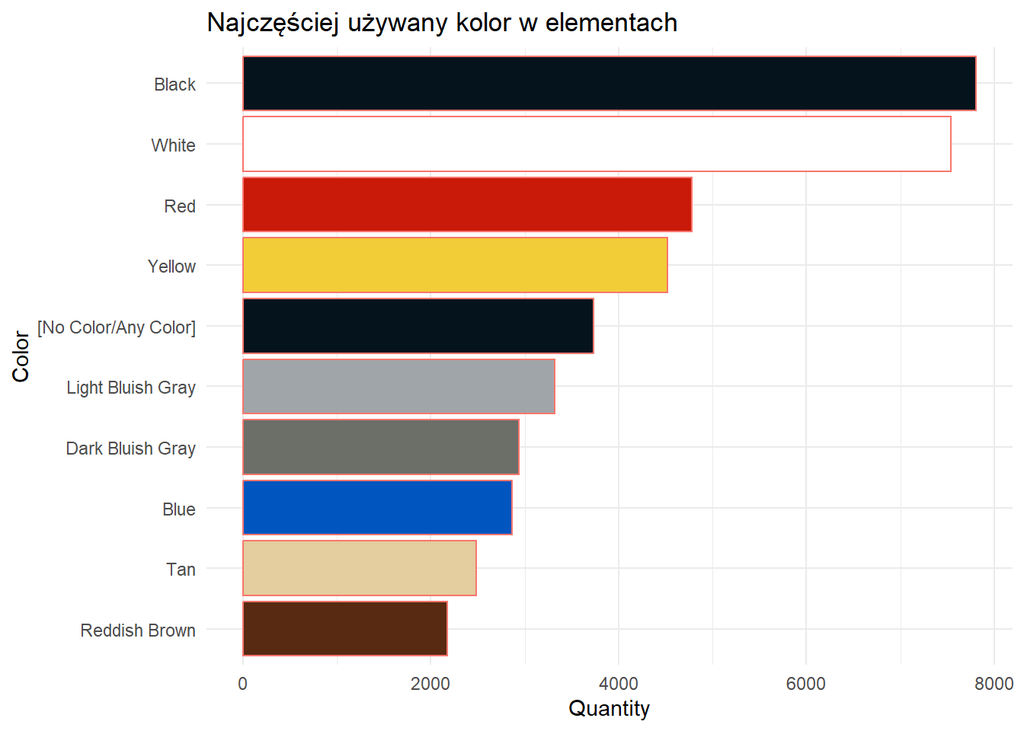